# DATA 101 Exam 1

Shreehar Joshi

Due: Monday 10/26 at 11:59pm

## Academic Honesty Statement (fill in your name)

I, Shreehar Joshi, hereby affirm that I have not communicated with or gained information in any way from my classmates or anyone other than the Professor during this exam, that I have not assisted anyone else with this exam, and that all work is my own.

## Load packages and data

```r
library(tidyverse)
```

```r
nba <- read_csv("data/nba_salaries.csv")
```

## Questions

### Question 1

The highest paid players for the NBA 2015-2016 season are as follows:

```r
nba %>%
  arrange(desc(salary))
```

| player | position | team | salary |
| --- | --- | --- | --- |
| Kobe Bryant | SF | Los Angeles Lakers | 25.000000 |
| Joe Johnson | SF | Brooklyn Nets | 24.894863 |
| LeBron James | SF | Cleveland Cavaliers | 22.970500 |
| Carmelo Anthony | SF | New York Knicks | 22.875000 |
| Dwight Howard | C | Houston Rockets | 22.359364 |
| Chris Bosh | PF | Miami Heat | 22.192730 |
| Chris Paul | PG | Los Angeles Clippers | 21.468695 |
| Kevin Durant | SF | Oklahoma City Thunder | 20.158622 |
| Derrick Rose | PG | Chicago Bulls | 20.093064 |
| Dwyane Wade | SG | Miami Heat | 20.000000 |

[output cut: 407 more lines]

Kobe Bryant had the highest salary of 25.0 million USD per year in the NBA season 2015-2016. He was followed by Joe Johnson and LeBron James each with the salary of 24.9 and 23.0 million USD per year respectively. All the top three highest paid players played in the “Small Forward” position.

### Question 2

Now, lets visualize the distribution of salaries based on position in the NBA 2015-2016.

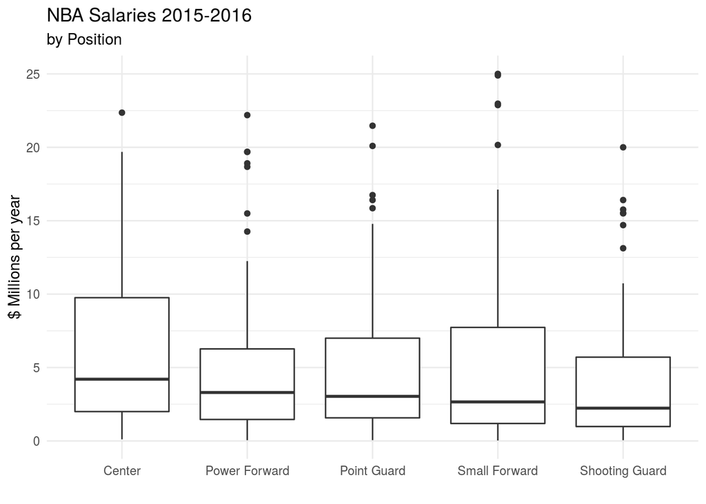

```r
nba %>%
  ggplot(aes(x = position, y = salary)) +
  geom_boxplot() +
  theme_minimal() +
  scale_x_discrete(labels = c("C" = "Center",
                              "PG" = "Point Guard",
                              "SG" = "Shooting Guard",
                              "PF" = "Power Forward",
                              "SF" = "Small Forward")) +
  #Reference (https://ggplot2.tidyverse.org/reference/scale_discrete.html)
  labs(
    x = " ",
    y = "$ Millions per year",
    title = "NBA Salaries 2015-2016",
    subtitle = "by Position"
  )
```

### Question 3

Now lets find out the number of players that play in each position.

```r
nba %>%
  count(position)
```

| position | n |
| --- | --- |
| C | 69 |
| PF | 85 |
| PG | 85 |
| SF | 82 |
| SG | 96 |

The table above shows that the number of players in Center, Power Forward, Point Guard, Small Forward, and Shooting Guard are 69, 85, 85, 82, and 96 respectively.

Finally, lets visualize the number of players in each position.

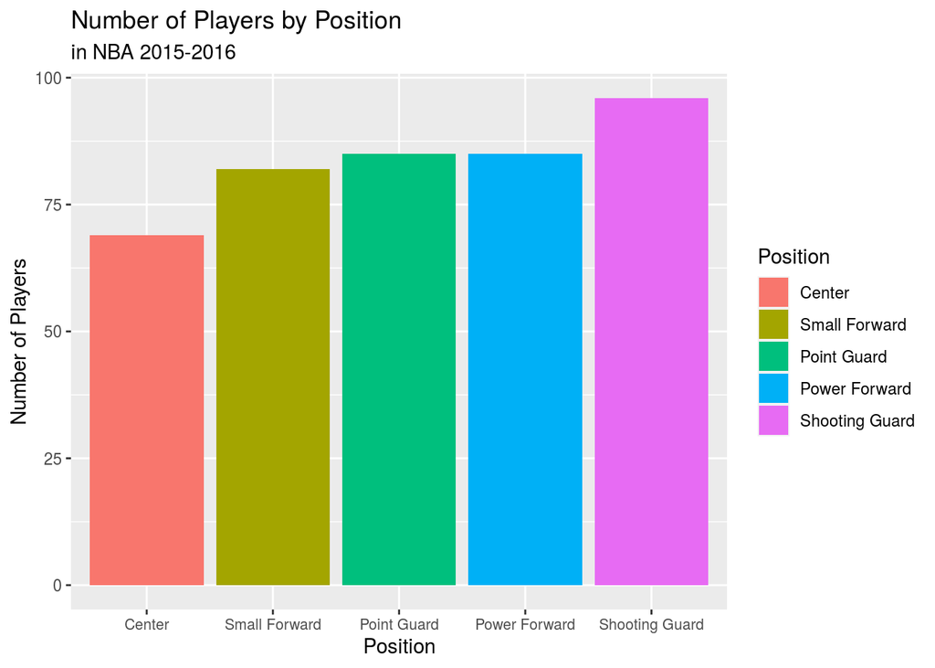

```r
nba %>%
  ggplot(aes(x = fct_rev(fct_infreq(position)),
             fill = fct_rev(fct_infreq(position)))) +
  geom_bar() +
  theme(axis.text.x = element_text(size = 8)) +
  #Reference (http://www.cookbook-r.com/Graphs/Axes_(ggplot2)/)
  scale_x_discrete(labels = c("C" = "Center",
                              "PG" = "Point Guard",
                              "SG" = "Shooting Guard",
                              "PF" = "Power Forward",
                              "SF" = "Small Forward")) +
  #Reference (https://ggplot2.tidyverse.org/reference/scale_discrete.html)
  scale_fill_discrete(labels = c("C" = "Center",
                                 "PG" = "Point Guard",
                                 "SG" = "Shooting Guard",
                                 "PF" = "Power Forward",
                                 "SF" = "Small Forward")) +
  #Reference (http://www.cookbook-r.com/Graphs/Legends_(ggplot2)/)
  labs(
    x = "Position",
    y = "Number of Players",
    title = "Number of Players by Position",
    subtitle = "in NBA 2015-2016",
    fill = "Position"
  )
```

### Question 4

Now, lets visualize the distribution of players’ salaries.

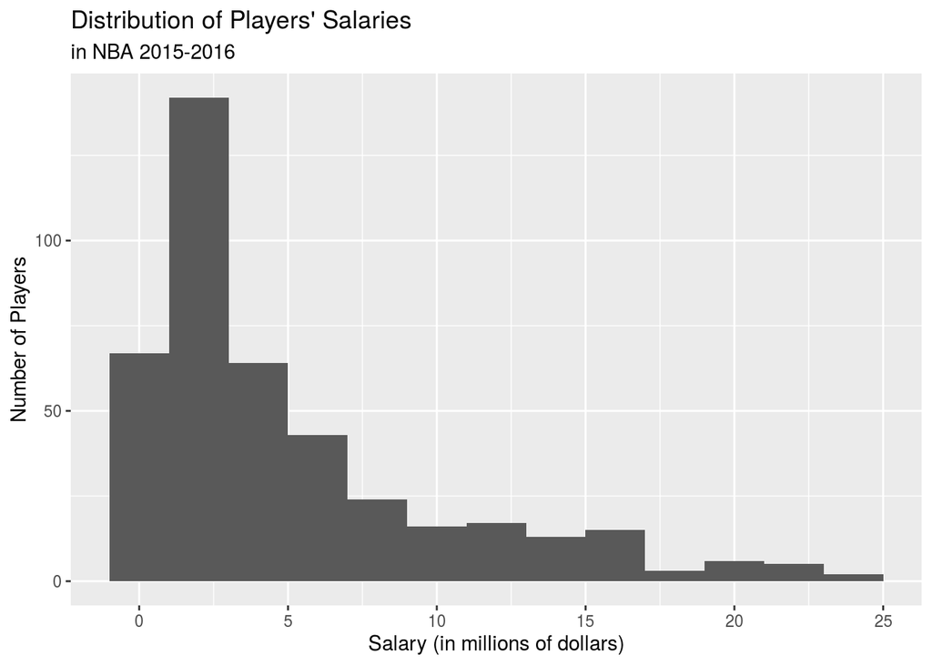

```r
nba %>%
  ggplot(aes(x = salary)) +
  geom_histogram(binwidth = 2) +
  labs(
    x = "Salary (in millions of dollars)",
    y = "Number of Players",
    title = "Distribution of Players' Salaries",
    subtitle = "in NBA 2015-2016"
  )
```

### Question 5

Now lets find the average player salary for the top 10 highest paying teams.

```r
nba %>%
  group_by(team) %>%
  summarise(avg_salary = mean(salary)) %>%
  arrange(desc(avg_salary)) %>%
  top_n(10)
```

| team | avg_salary |
| --- | --- |
| Cleveland Cavaliers | 10.231241 |
| Houston Rockets | 7.107153 |
| Miami Heat | 6.794056 |
| Golden State Warriors | 6.720367 |
| Chicago Bulls | 6.568408 |
| San Antonio Spurs | 6.511698 |
| Los Angeles Lakers | 6.237086 |
| Sacramento Kings | 6.216808 |
| Oklahoma City Thunder | 6.052010 |
| Dallas Mavericks | 5.978414 |

Cleveland Cavaliers had the average salary of 10.2 million USD per year, which was the highest for a team. It was followed by Houston Rockets and Miami Heats in the second and third position with average salaries of 7.11 million and 6.79 million USD per year respectively.

### Question 6

Now, lets classify the salaries of the players into “Low”, “Moderate”, and “High”.

```r
nba_salary <- nba %>%
  mutate(salary_level = case_when(
    salary < 8                ~ "Low",
    salary >= 8 & salary < 16 ~ "Moderate",
    salary >= 16              ~ "High"
  ))
```

After this, lets calculate the proportion of players at each salary level.

```r
nba_salary %>%
  count(salary_level, sort = TRUE) %>%
  mutate(prop_players = n / sum(n))
```

| salary_level | n | prop_players |
| --- | --- | --- |
| Low | 326 | 0.78177458 |
| Moderate | 69 | 0.16546763 |
| High | 22 | 0.05275779 |

Majority of players have “Low” salary as their proportion is 0.782, which is the highest. Only a few players have a “High” salary as their proportion is 0.0528, which is the least. The proportion of players whose salary is classified as “Medium” is 0.165 and it falls in between the proportion of players that have “High” and “Low” salaries.

### Question 7

Now lets create a dataframe to store the starting lineup salaries of each team.

```r
starters <- nba %>%
  select (-player) %>%
  group_by(team, position) %>%
  filter(salary == max(salary)) %>%
  distinct() %>%
  arrange(team, position) %>%
  ungroup()

starters
```

| position | team | salary |
| --- | --- | --- |
| C | Atlanta Hawks | 12.000000 |
| PF | Atlanta Hawks | 18.671659 |
| PG | Atlanta Hawks | 8.000000 |
| SF | Atlanta Hawks | 4.000000 |
| SG | Atlanta Hawks | 5.746479 |
| C | Boston Celtics | 2.616975 |
| PF | Boston Celtics | 5.000000 |
| PG | Boston Celtics | 7.730337 |
| SF | Boston Celtics | 6.796117 |
| SG | Boston Celtics | 3.425510 |

[output cut: 137 more lines]

Here, at first we removed “player” column by using select function in the nba dataframe. Then the dataframe was piped to be grouped on the basis of team and position. And then, we used filter function to find the maximum salary. Had we just grouped on the basis of team, then the maximum salary on the basis of teams would have been filtered instead of filtering the maximum salary on the basis of each positions in each teams. After the filter function, the distinct function is used that avoids any repetition of highest salaries by selecting only the unique rows. The distinct function is followed by arrange function to sort the output alphabetically first by team name and then by position. Finally, we use the ungroup function to remove the groupings in the resulting dataframe, which we have named as starters.

### Question 8

Now, adding a column with appropriate player names to the starters dataframe by left joining it with nba dataframe.

```r
starters <- left_join(starters, nba)
starters
```

| position | team | salary | player |
| --- | --- | --- | --- |
| C | Atlanta Hawks | 12.000000 | Al Horford |
| PF | Atlanta Hawks | 18.671659 | Paul Millsap |
| PG | Atlanta Hawks | 8.000000 | Jeff Teague |
| SF | Atlanta Hawks | 4.000000 | Thabo Sefolosha |
| SG | Atlanta Hawks | 5.746479 | Kyle Korver |
| C | Boston Celtics | 2.616975 | Tyler Zeller |
| PF | Boston Celtics | 5.000000 | Jonas Jerebko |
| PG | Boston Celtics | 7.730337 | Avery Bradley |
| SF | Boston Celtics | 6.796117 | Jae Crowder |
| SG | Boston Celtics | 3.425510 | Evan Turner |

[output cut: 138 more lines]

Here, we used left join to join the two dataframes (starters and nba). In this type of join, all rows from starters dataframe are returned along with the matching rows from nba dataframe.

### Question 9

We can count the number of players in each of position in each of the teams and if we find any position with more than 1 value in any team, then we can conclude that the team has multiple starters in a single position.

```r
starters %>%
  count(team, position) %>%
  filter(n > 1)
```

| team | position | n |
| --- | --- | --- |
| Indiana Pacers | C | 2 |

In the team Indiana Pacers, the Center position had two players with the same highest salary.

### Question 10

Finally, lets view the teams with the name of their players with highest salaries in each position.

```r
starters_unique <- starters %>%
  filter(player != "Ian Mahinmi") %>%
  pivot_wider(-salary, names_from = position, values_from = player)

knitr::kable(starters_unique,
             col.names = c("Team",
                           "Center",
                           "Power Forward",
                           "Point Guard",
                           "Small Forward",
                           "Shooting Guard"))
```

| Team | Center | Power Forward | Point Guard | Small Forward | Shooting Guard |
| --- | --- | --- | --- | --- | --- |
| Atlanta Hawks | Al Horford | Paul Millsap | Jeff Teague | Thabo Sefolosha | Kyle Korver |
| Boston Celtics | Tyler Zeller | Jonas Jerebko | Avery Bradley | Jae Crowder | Evan Turner |
| Brooklyn Nets | Andrea Bargnani | Thaddeus Young | Jarrett Jack | Joe Johnson | Bojan Bogdanovic |
| Charlotte Hornets | Al Jefferson | Marvin Williams | Kemba Walker | Michael Kidd-Gilchrist | Nicolas Batum |
| Chicago Bulls | Joakim Noah | Nikola Mirotic | Derrick Rose | Doug McDermott | Jimmy Butler |
| Cleveland Cavaliers | Tristan Thompson | Kevin Love | Kyrie Irving | LeBron James | Iman Shumpert |
| Dallas Mavericks | Zaza Pachulia | David Lee | Deron Williams | Chandler Parsons | Justin Anderson |
| Denver Nuggets | JJ Hickson | Kenneth Faried | Jameer Nelson | Danilo Gallinari | Gary Harris |
| Detroit Pistons | Aron Baynes | NA | Reggie Jackson | Stanley Johnson | Jodie Meeks |
| Golden State Warriors | Andrew Bogut | Draymond Green | Stephen Curry | Andre Iguodala | Klay Thompson |
| Houston Rockets | Dwight Howard | Terrence Jones | Ty Lawson | Trevor Ariza | James Harden |
| Indiana Pacers | Jordan Hill | Lavoy Allen | Rodney Stuckey | Paul George | Monta Ellis |
| Los Angeles Clippers | Cole Aldrich | Blake Griffin | Chris Paul | Paul Pierce | J.J. Redick |
| Los Angeles Lakers | Roy Hibbert | Julius Randle | D’Angelo Russell | Kobe Bryant | Louis Williams |
| Memphis Grizzlies | Marc Gasol | Zach Randolph | Mike Conley | Jeff Green | Tony Allen |
| Miami Heat | NA | Chris Bosh | Goran Dragic | Luol Deng | Dwyane Wade |
| Milwaukee Bucks | Miles Plumlee | Jabari Parker | Greivis Vasquez | Giannis Antetokounmpo | Khris Middleton |
| Minnesota Timberwolves | Nikola Pekovic | Kevin Garnett | Ricky Rubio | Shabazz Muhammad | Kevin Martin |
| New Orleans Pelicans | Omer Asik | Ryan Anderson | Jrue Holiday | Quincy Pondexter | Eric Gordon |
| New York Knicks | Robin Lopez | Kristaps Porzingis | Jose Calderon | Carmelo Anthony | Arron Afflalo |
| Oklahoma City Thunder | Enes Kanter | Serge Ibaka | Russell Westbrook | Kevin Durant | Dion Waiters |
| Orlando Magic | Nikola Vucevic | Channing Frye | Brandon Jennings | Tobias Harris | Victor Oladipo |
| Philadelphia 76ers | Joel Embiid | Carl Landry | Kendall Marshall | Gerald Wallace | Nik Stauskas |
| Phoenix Suns | Tyson Chandler | Mirza Teletovic | Eric Bledsoe | P.J. Tucker | Devin Booker |
| Portland Trail Blazers | Ed Davis | Meyers Leonard | Damian Lillard | Al-Farouq Aminu | Gerald Henderson |
| Sacramento Kings | DeMarcus Cousins | NA | Rajon Rondo | Rudy Gay | Marco Belinelli |
| San Antonio Spurs | Boris Diaw | LaMarcus Aldridge | Tony Parker | Kawhi Leonard | Danny Green |
| Toronto Raptors | Jonas Valanciunas | Patrick Patterson | Kyle Lowry | DeMarre Carroll | DeMar DeRozan |
| Utah Jazz | Tibor Pleiss | Trevor Booker | Dante Exum | Gordon Hayward | Alec Burks |
| Washington Wizards | Nene Hilario | Markieff Morris | John Wall | Martell Webster | Bradley Beal |

```r
#Reference (https://bookdown.org/yihui/rmarkdown-cookbook/kable.html)
```

The starters dataframe, at first, is piped into a filter function which removes the record for the player “Ian Mahinmi”. Then the resulting dataframe is pivoted using pivot_wider function. The first argument passed in this function removes the salary column. The second and third arguments will create columns with names from position and the values for those newly created columns taken from players’ names. In the end, knitr:kable function is used to print the entire table.

```r
nba %>%
  summarise(salary_avg = mean(salary))
```

| salary_avg |
| --- |
| 5.074814 |